# WTP Model first pass

This is a first-pass attempt to model willingness to pay data. Let’s put the code together, WITHOUT testing the data, then consider pre-registration and then a test.

What are we pre-registering? Something like: - health and liking scores predict payment scores significantly better than either choice alone - hunger ratings moderate liking, so that an interaction term can be observed between liking and hunger when predicting bid, indicating that liking is more important for predicting the bid score when participants are hungrier. - hunger ratings also moderate the influence of health, so that an interaction can be observed between liking and hunger when predicting bids so that when participants are hungrier liking is less important

To model these data, we’ll use a multi-level model, where we predict individual bid based on health and liking score. At the participant level, we’ll model hunger.

Do we model any other participant factors? These might include:

- obesity level
- demographics (sex/gender, age, income)
- PSS

With only ~200 subjects, we’re probably under-specified to test *interactions* with more than a couple of participant-level variables.

Any other subject-level variables that might interact to predict greater predictivity of liking vs. health?

self control - impulsivity scale - self control scale - tempest self regulation scale for eating - restraint scale

food scarcity - childhood financial security - adult food security scale

reward sensitivity - Food Craving Inventory

Food habits - Food Frequency Inventory

Before testing each of these we may want to run some sort of correlation on them to look at the correlations between the scales. If items are uncorrelated, we could include them together in a single regression. If they are correlated, we might want to avoid testing them together, test their interaction, or pick one scale over another to analyze.

## original question

From our teams script the orignla question is

> We asked you to not eat for 3 hours prior to this appointment and to refrain from liquids for the past hour. Were you able to do that?

> And how hungry are you currently feeling on a scale from 1-5 where 1 = not hungry at all and 5 = extremely hungry?

> Record answer in Redcap

> Great! We would like you to continue fasting prior to the body composition assessment to obtain the most accurate results. After you complete the physical assessments, you’ll be able to drink fluids and after the MRI scan, we’ll provide you with a snack.

> We have a couple minutes before we need to get started. Would you like to visit the restroom or do you need anything before we get started?

> Do you have any questions for me before we start gathering some of the measurements?

## Implementation

### First: group-level predictors

In linear modeling terms what we are looking for is a *varying slope*; the varying slope will have a *group-level predictor* (e.g., hunger).

See Gelman & Hill, 12.6: group-level predictors; also 13.1.

### Next: interaction of group-level predictor

this is discussed in 13.1

What we have isn’t analogous to the simple radon problem, where we’res predicting indiviual-level (house) radon level from an individual-level predictor (floor=0 or 1) and a group-level (county) predictor. That would be analogous to predicting bid size based on hunger, food health, and food likeability separately. And I think, in a model, this would be using a group predictor to model the intercept of the individual level prediction.

Rather we want to get an interaction of the group-level predictor with the individual-level predictor. In the radon example, this would be like looking for an interaction between floor and county-level radon level.

In a multi-level model this isn’t too complicated, right–it’s just including the group-level item as a predictor of the group-level variable. This might be descrribed as predicting the slope $\beta_j$.

Gelman *still* doesn’t spell out the form for this in lme4 or lmer, though he does discuss it extensively. So. a quick google…

brief discussion here: https://biologyforfun.wordpress.com/2017/06/19/adding-group-level-predictors-in-glmm-using-lme4/ - not high quality and they specifically caution against using p-values ot test significance. Wonder if Gelman knows how to do it.

Gelman covers this in Section 17.2: varying intercepts and slopes with group-level predictors. He only offers Bugs code, though. We might use stan.

Can try: https://cran.r-project.org/web/packages/equatiomatic/vignettes/lme4-lmer.html

See also: https://github.com/lme4/lme4/issues/473

hmmm…so, individual-level predictors are food healthiness and tastiness. we might add RT but let’s keep it simple for now.

Let’s get some data.

```r
Sys.setenv(R_CONFIG_ACTIVE = Sys.info()["nodename"])
data_dir <- config::get("dev_analysis_data_dir")
#hunger data
setwd(paste0(paste0(data_dir,"hunger/")))
source("DEV-Session1Data_R_2022-04-19_2347.r")
redcap_data<-data
rm(data)
```

```r
Sys.setenv(R_CONFIG_ACTIVE = Sys.info()["nodename"])
data_dir <- config::get("dev_analysis_data_dir")

library(readr)
wtp_raw <- read_csv(paste0(data_dir,"wtp_behavdesign_clean.csv"))
```

```
* `` -> ...1
```

```r
library(dplyr)
table(redcap_data$hunger_1)
```

```
 1  2  3  4  5
38 76 73 51 14
```

```r
session_1_redcap_data <-redcap_data %>% filter(grepl("session_1", redcap_event_name))
hunger_data <- session_1_redcap_data %>% select(dev_id,hunger_1)

regress_data<-merge(wtp_raw,hunger_data,by.x="subject",by.y="dev_id",all.x = TRUE,all.y=FALSE)
```

Now let’s adapt the columns to normed columns with hte names we used in the synthetic dtaset.

```r
#regress_data<-regress_data[1:1000,]
regress_data[regress_data$response=="NULL","response"] <- NA
regress_data$response<-as.numeric(regress_data$response)
regress_data <- regress_data%>% group_by(subject,run,wave) %>% mutate(min_response=min(response,na.rm=TRUE),max_response=max(response,na.rm=TRUE)) %>% ungroup()
```

[output not shown]

[output cut: 233 more lines]

[output not shown]

```r
regress_data$response_range <- regress_data$max_response - regress_data$min_response
stopifnot(max(regress_data$response_range)==3)#max of the max range should be 3 exactly, the range from the max response minus the min response
#there are two groups of responses here grouped by run
#some use range 1,2,3,4; others use range 5,6,7,8
#we need to combine those for value.
value_adjustment <- 0 - 4*(regress_data$min_response>4)
regress_data$value_level <- regress_data$response + value_adjustment
#regress_data$value <- factor(regress_data$value_level,levels = c(1,2,3,4),labels="$0.00","$0.50","$1.00","$1.50")

regress_data[regress_data$liking_rating==0,"liking_rating"]<-NA
table(regress_data$value_level)
```

```
    1     2     3     4
14811 11353  9869  7020
```

```r
#must have tried for half an hour to et this to work within the loop and it didn't...
standardize<-function(x){return((x-mean(x,na.rm=TRUE))/sd(x,na.rm=TRUE))}

regress_data$bid <- (regress_data$value_level-1)*0.5
regress_data$bid_norm <- standardize(regress_data$bid)

regress_data$health_rating <- factor(regress_data$health_cond)
regress_data$liking_rating_norm <- standardize(regress_data$liking_rating)

regress_data$hunger_norm <- standardize(regress_data$hunger_1)
```

````r
```r
library(lme4)
````

Loading required package: Matrix package ‘Matrix’ was built under R version 4.0.5

````
```r
```r
model <- lme4::lmer(
  bid_norm ~ health_rating + liking_rating_norm + (1 | subject),
  regress_data
  )
summary(model)
````

Linear mixed model fit by REML [‘lmerMod’] Formula: bid_norm ~ health_rating + liking_rating_norm + (1 | subject) Data: regress_data

REML criterion at convergence: 93342.7

Scaled residuals: Min 1Q Median 3Q Max -3.6412 -0.6650 -0.1049 0.7008 3.9393

Fixed effects: Estimate Std. Error t value (Intercept) 0.199274 0.018742 10.63 health_ratingunhealthy -0.340588 0.007095 -48.00 liking_rating_norm 0.602969 0.003669 164.33

Correlation of Fixed Effects: (Intr) hlth_r hlth_rtngnh -0.186  
lkng_rtng_n -0.020 0.124

````
```r

hist(regress_data$hunger_1)
````

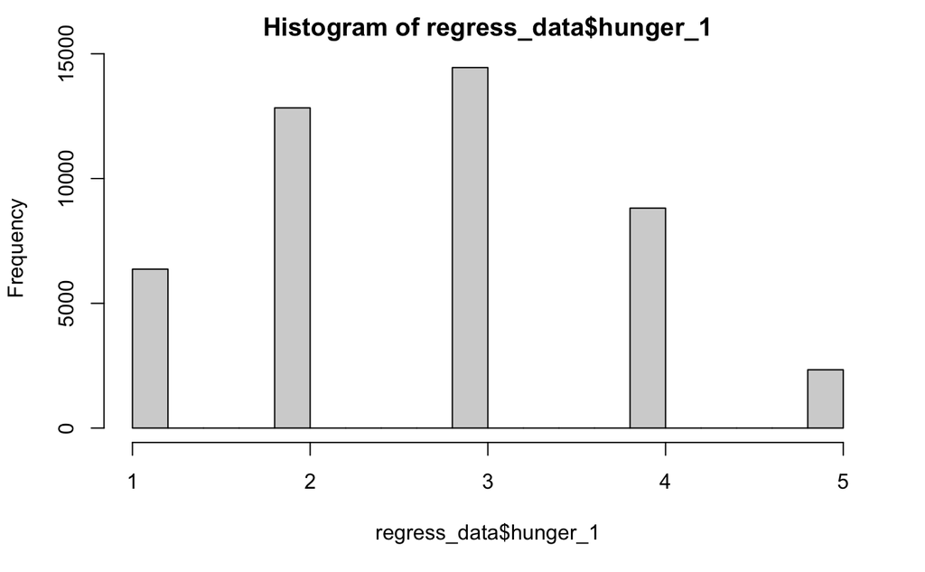

```r
mean_by_food <- regress_data %>% #filter(health_cond=="unhealthy") %>%
  group_by(food_pic) %>% summarise(
  #hunger=mean(hunger_1,na.rm=TRUE),
  liking_for_food = mean(liking_rating,na.rm=TRUE),
  bid=mean(bid,na.rm=TRUE)
  )

cor.test(mean_by_food$liking_for_food,mean_by_food$bid)
```

```
    Pearson's product-moment correlation

data:  mean_by_food$liking_for_food and mean_by_food$bid
t = 17.905, df = 98, p-value < 2.2e-16
alternative hypothesis: true correlation is not equal to 0
95 percent confidence interval:
 0.8196128 0.9143849
sample estimates:
      cor
0.8751443
```

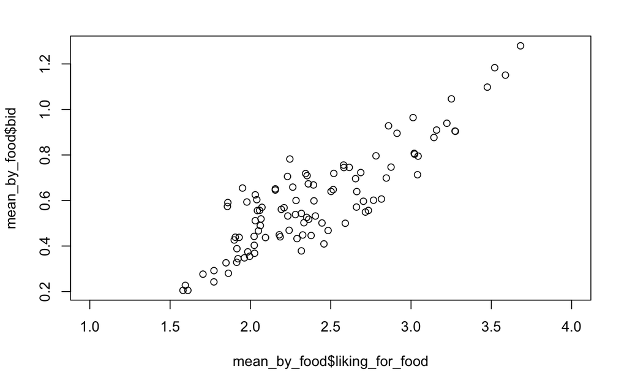

```r
plot(mean_by_food$liking_for_food,mean_by_food$bid)
```

```r
mean_by_subject <- regress_data %>% filter(health_cond=="unhealthy" & liking_rating==4) %>% group_by(subject) %>% summarise(
  hunger=mean(hunger_1,na.rm=TRUE),
  bid=mean(bid,na.rm=TRUE)
  )

cor.test(mean_by_subject$hunger,mean_by_subject$bid)
```

```
    Pearson's product-moment correlation

data:  mean_by_subject$hunger and mean_by_subject$bid
t = -0.17589, df = 187, p-value = 0.8606
alternative hypothesis: true correlation is not equal to 0
95 percent confidence interval:
 -0.1553062  0.1301081
sample estimates:
        cor
-0.01286098
```

[figure not shown]

```r
plot(mean_by_subject$hunger,mean_by_subject$bid)
```

We don’t really care whether or not there are individual-level differences in the interaction between taste ratings and hunger norms. we just want to know, overall, whether they interact and whether modeling that interaction can make the model more predictive.

In fact, individual-level differences in interaction between taste ratings and hunger norms don’t make sense. there aren’t individual-level differences because there’s not an interaction ath the individual-level because there’s only one hunger norm per subject. So it’s nonsensical to include group-level variables in that bracket.

````r
```r
library(lme4)

model1 <- lme4::lmer(
  bid_norm ~ run + health_rating + liking_rating_norm + hunger_norm + (1+ liking_rating_norm + health_rating | subject),
  regress_data
  )
summary(model1)
````

Linear mixed model fit by REML [‘lmerMod’] Formula: bid_norm ~ run + health_rating + liking_rating_norm + hunger_norm + (1 + liking_rating_norm + health_rating | subject) Data: regress_data

REML criterion at convergence: 87820.8

Scaled residuals: Min 1Q Median 3Q Max -3.6580 -0.6590 -0.0729 0.6392 4.0385

Random effects: Groups Name Variance Std.Dev. Corr  
subject (Intercept) 0.10460 0.3234  
liking_rating_norm 0.02088 0.1445 0.06  
health_ratingunhealthy 0.15668 0.3958 -0.60 0.33 Residual 0.46667 0.6831  
Number of obs: 41506, groups: subject, 206

Fixed effects: Estimate Std. Error t value (Intercept) 0.145653 0.023692 6.148 runrun2 0.036189 0.007856 4.607 runrun3 0.095318 0.010824 8.806 runrun4 0.072971 0.010819 6.745 health_ratingunhealthy -0.304649 0.028744 -10.599 liking_rating_norm 0.604727 0.010933 55.311 hunger_norm -0.011654 0.017352 -0.672

Correlation of Fixed Effects: (Intr) runrn2 runrn3 runrn4 hlth_r lkng__ runrun2 -0.165  
runrun3 -0.132 0.363  
runrun4 -0.132 0.363 0.285  
hlth_rtngnh -0.598 -0.001 -0.001 -0.001  
lkng_rtng_n 0.043 -0.003 -0.005 -0.003 0.313  
hunger_norm 0.013 0.001 -0.001 0.001 0.000 0.005

````
```r
```r
#coef(model1)
````

````
That's a non-significant effect for hunger. It is in the reverse direction to what we'd predict. But we weren't interestd in the main effct, particularly. What does it do as an interaction term?



```r

model2 <- lme4::lmer(
  bid_norm ~ run + health_rating + liking_rating_norm*hunger_norm + (1 + liking_rating_norm | food_pic) + (1+ liking_rating_norm + health_rating | subject),
  regress_data
  )
````

```r
summary(model2)
```

[output not shown]

````r
```r

model3 <- lme4::lmer(
  bid_norm ~ run + health_rating*hunger_norm + liking_rating_norm*hunger_norm + (1+ liking_rating_norm + health_rating | subject),
  regress_data
  )

summary(model3)
````

Linear mixed model fit by REML [‘lmerMod’] Formula: bid_norm ~ run + health_rating * hunger_norm + liking_rating_norm *  
hunger_norm + (1 + liking_rating_norm + health_rating | subject) Data: regress_data

REML criterion at convergence: 87832.7

Scaled residuals: Min 1Q Median 3Q Max -3.6584 -0.6590 -0.0724 0.6389 4.0393

Random effects: Groups Name Variance Std.Dev. Corr  
subject (Intercept) 0.10487 0.3238  
liking_rating_norm 0.02094 0.1447 0.06  
health_ratingunhealthy 0.15724 0.3965 -0.60 0.33 Residual 0.46667 0.6831  
Number of obs: 41506, groups: subject, 206

Fixed effects: Estimate Std. Error t value (Intercept) 0.145684 0.023721 6.142 runrun2 0.036189 0.007856 4.607 runrun3 0.095316 0.010824 8.806 runrun4 0.072972 0.010819 6.745 health_ratingunhealthy -0.304919 0.028796 -10.589 hunger_norm -0.006987 0.023042 -0.303 liking_rating_norm 0.604596 0.010948 55.223 health_ratingunhealthy:hunger_norm -0.016260 0.028482 -0.571 hunger_norm:liking_rating_norm -0.008167 0.010874 -0.751

Correlation of Fixed Effects: (Intr) runrn2 runrn3 runrn4 hlth_r hngr_n lkng__ hlt_: runrun2 -0.165  
runrun3 -0.132 0.363  
runrun4 -0.132 0.363 0.285  
hlth_rtngnh -0.599 -0.001 -0.001 -0.001  
hunger_norm 0.018 0.000 -0.001 0.001 -0.011  
lkng_rtng_n 0.044 -0.003 -0.005 -0.003 0.311 0.003  
hlth_rtng: -0.011 0.000 0.000 0.000 0.018 -0.611 0.006  
hngr_nrm:__ 0.003 0.000 0.000 0.000 0.006 0.042 0.014 0.309

````
```r
```r
anova(model1, model2, model3)
````

refitting model(s) with ML (instead of REML) Data: regress_data Models: model1: bid_norm ~ run + health_rating + liking_rating_norm + hunger_norm + (1 + liking_rating_norm + health_rating | subject) model2: bid_norm ~ run + health_rating + liking_rating_norm * hunger_norm + (1 + liking_rating_norm + health_rating | subject) model3: bid_norm ~ run + health_rating * hunger_norm + liking_rating_norm * hunger_norm + (1 + liking_rating_norm + health_rating | subject) npar AIC BIC logLik deviance Chisq Df Pr(>Chisq) model1 14 87801 87922 -43887 87773  
model2 15 87803 87932 -43886 87773 0.3653 1 0.5456 model3 16 87804 87943 -43886 87772 0.3295 1 0.5659

````
Alright. miserable :-(


## Some investigation of a simpler model.


```r
```r

model3a <- lme4::lmer(
  bid_norm ~ run + health_rating + liking_rating_norm + (1 | subject),
  regress_data[!is.na(regress_data$hunger_norm),]
  )

summary(model3a)
````

Linear mixed model fit by REML [‘lmerMod’] Formula: bid_norm ~ run + health_rating + liking_rating_norm + (1 | subject) Data: regress_data[!is.na(regress_data$hunger_norm), ]

REML criterion at convergence: 91303.9

Scaled residuals: Min 1Q Median 3Q Max -3.6708 -0.6573 -0.0987 0.7008 3.9999

Random effects: Groups Name Variance Std.Dev. subject (Intercept) 0.06483 0.2546  
Residual 0.51961 0.7208  
Number of obs: 41506, groups: subject, 206

Fixed effects: Estimate Std. Error t value (Intercept) 0.156378 0.019171 8.157 runrun2 0.037636 0.008284 4.543 runrun3 0.093800 0.011413 8.218 runrun4 0.074681 0.011408 6.546 health_ratingunhealthy -0.338107 0.007145 -47.322 liking_rating_norm 0.605582 0.003692 164.045

Correlation of Fixed Effects: (Intr) runrn2 runrn3 runrn4 hlth_r runrun2 -0.215  
runrun3 -0.172 0.363  
runrun4 -0.172 0.363 0.285  
hlth_rtngnh -0.182 -0.004 -0.003 -0.005  
lkng_rtng_n -0.016 -0.010 -0.010 -0.009 0.122

````
Health ratings are the same for every subject, so it makes no sense to model the interaction of health_rating and hunger.


```r
```r

model3b <- lme4::lmer(
  bid_norm ~ run + health_rating + liking_rating_norm*hunger_norm + (1 | subject),
  regress_data[!is.na(regress_data$hunger_norm),]
  )

summary(model3b)
````

Linear mixed model fit by REML [‘lmerMod’] Formula: bid_norm ~ run + health_rating + liking_rating_norm * hunger_norm + (1 | subject) Data: regress_data[!is.na(regress_data$hunger_norm), ]

REML criterion at convergence: 91313.6

Scaled residuals: Min 1Q Median 3Q Max -3.6494 -0.6602 -0.0956 0.6986 3.9801

Random effects: Groups Name Variance Std.Dev. subject (Intercept) 0.0649 0.2548  
Residual 0.5196 0.7208  
Number of obs: 41506, groups: subject, 206

Fixed effects: Estimate Std. Error t value (Intercept) 0.156259 0.019182 8.146 runrun2 0.037616 0.008284 4.541 runrun3 0.093784 0.011413 8.218 runrun4 0.074656 0.011407 6.545 health_ratingunhealthy -0.338506 0.007147 -47.365 liking_rating_norm 0.605532 0.003691 164.036 hunger_norm -0.017899 0.018017 -0.993 liking_rating_norm:hunger_norm -0.008228 0.003711 -2.217

Correlation of Fixed Effects: (Intr) runrn2 runrn3 runrn4 hlth_r lkng__ hngr_n runrun2 -0.215  
runrun3 -0.172 0.363  
runrun4 -0.172 0.363 0.285  
hlth_rtngnh -0.182 -0.004 -0.003 -0.005  
lkng_rtng_n -0.016 -0.010 -0.010 -0.009 0.122  
hunger_norm 0.017 0.000 -0.001 0.001 0.000 0.000  
lkng_rtn_:_ -0.005 0.001 0.001 0.000 0.025 0.006 0.002

````
```r
```r
anova(model3a,model3b)
````

refitting model(s) with ML (instead of REML) Data: regress_data[!is.na(regress_data$hunger_norm), ] Models: model3a: bid_norm ~ run + health_rating + liking_rating_norm + (1 | subject) model3b: bid_norm ~ run + health_rating + liking_rating_norm * hunger_norm + (1 | subject) npar AIC BIC logLik deviance Chisq Df Pr(>Chisq)  
model3a 8 91274 91343 -45629 91258  
model3b 10 91272 91358 -45626 91252 5.9007 2 0.05232 . — Signif. codes: 0 ‘**’ 0.001 ‘**’ 0.01 ‘’ 0.05 ‘.’ 0.1 ‘ ’ 1

````
## Some visualization




```r
```r
library(ggplot2)
data_by_subj <- regress_data[!is.na(regress_data$hunger_norm),] %>%
         group_by(subject) %>%
         summarize(
           subj_liking_rating_norm = mean(liking_rating_norm,na.rm=TRUE),
           subj_health_rating = mean(as.integer(health_rating),na.rm=TRUE),
           subj_bid_norm=mean(bid_norm,na.rm=TRUE),
           subj_bid=mean(bid,na.rm=TRUE),
           hunger = mean(hunger_1,na.rm=TRUE)
           )
````

````
OK. Let's plot slopes for liking and bid, by hunger...


```r
```r
data_by_subj$hunger_factor <- factor(data_by_subj$hunger)
ggplot(data_by_subj,
       aes(x=subj_bid, y=subj_liking_rating_norm, group=hunger_factor, color=hunger_factor)
       )+
  geom_smooth(method='lm', formula= y~x)+
  scale_x_continuous(name=\subject average bid\,labels = scales::dollar_format())+
  geom_point()+
  labs(main="subject average bid to subject liking rating: across subjects")
````

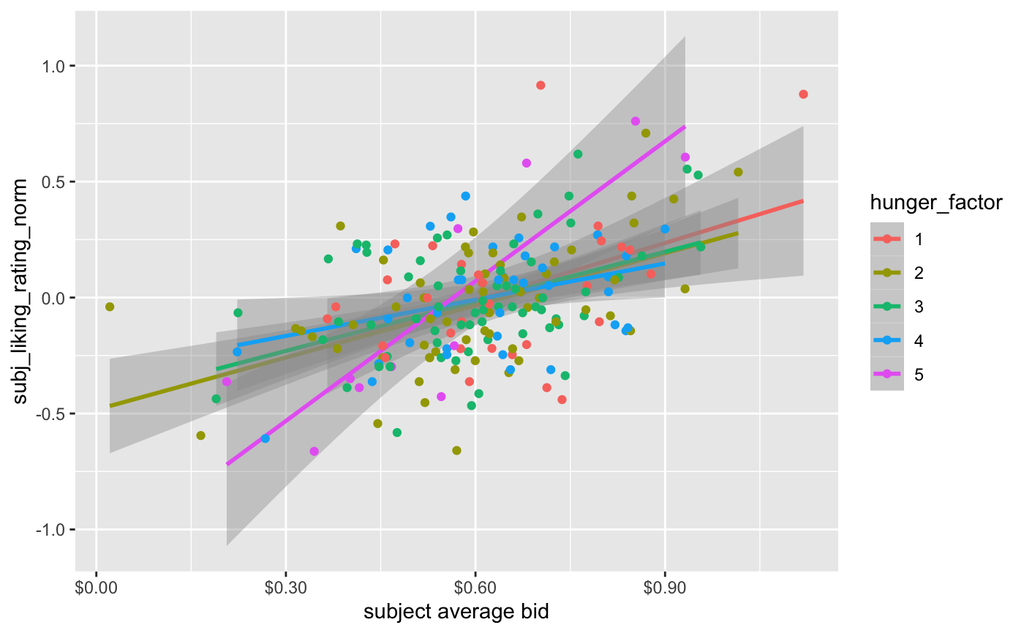

```r
NA
```

```r
summary(lm(subj_bid_norm~subj_liking_rating_norm*hunger,
           data_by_subj))
```

Call: lm(formula = subj_bid_norm ~ subj_liking_rating_norm * hunger, data = data_by_subj)

Residuals: Min 1Q Median 3Q Max -1.09030 -0.14631 0.00237 0.17298 0.54607

Coefficients: Estimate Std. Error t value Pr(>|t|)  
(Intercept) 0.04378 0.04792 0.914 0.36197  
subj_liking_rating_norm 0.41557 0.14717 2.824 0.00522 ** hunger -0.01267 0.01639 -0.773 0.44051  
subj_liking_rating_norm:hunger 0.05092 0.04777 1.066 0.28777  
— Signif. codes: 0 ‘**’ 0.001 ‘**’ 0.01 ‘’ 0.05 ‘.’ 0.1 ‘ ’ 1

Residual standard error: 0.2592 on 202 degrees of freedom (1 observation deleted due to missingness) Multiple R-squared: 0.296, Adjusted R-squared: 0.2855 F-statistic: 28.31 on 3 and 202 DF, p-value: 2.531e-15

````
```r
```r
regress_data$hunger_numeric<-as.numeric(regress_data$hunger_1)
````

````
```r
```r
ggplot(regress_data %>% filter(subject %in% names(table(regress_data$subject)[1:20])),
       aes(x=bid_norm, y=liking_rating_norm,color=hunger_numeric)) +
  geom_smooth(method='lm', formula= y~x) +
  geom_point()+
  #scale_x_continuous(name=\subject average bid\, labels = scales::dollar_format()) +
  facet_wrap(subject~.,nrow = 5)
````

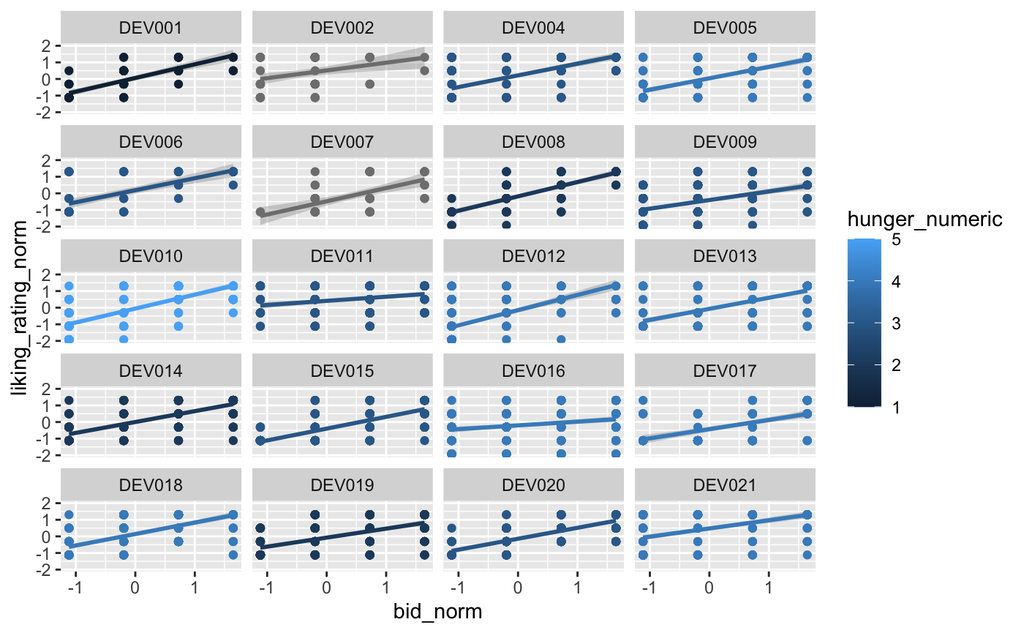

```r
NA
NA
```

````
```r
```r
````

````
```r
```r
regress_data$hunger_factor<-as.factor(regress_data$hunger_1)
ggplot(regress_data %>% filter(hunger_1 %in% c(1,5)) %>% filter(subject %in% names(table(.$subject)[1:100])),
       aes(x=liking_rating, y=bid,color=hunger_factor,group=subject)) +
  geom_line(stat=\smooth\,method = \lm\, formula = y ~ x,
              size = 0.5,
              se=FALSE,
              alpha = 0.5)
````

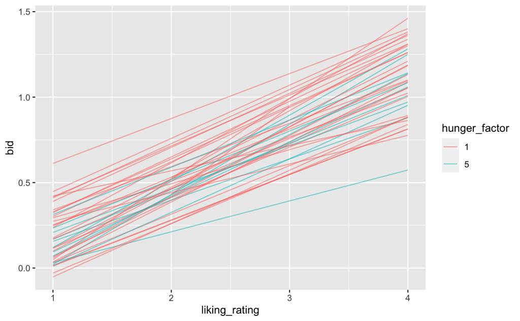

```r
  #geom_smooth(method='lm', formula= y~x,se=FALSE,alpha=0.2)

#table(regress_data$liking_rating)
```

[output not shown]

````
## no liking


```r
```r

model_no_liking <- lme4::lmer(
  bid_norm ~ run + health_rating + (1 + health_rating | subject),
  regress_data
  )

summary(model_no_liking)
````

Linear mixed model fit by REML [‘lmerMod’] Formula: bid_norm ~ run + health_rating + (1 + health_rating | subject) Data: regress_data

REML criterion at convergence: 112842

Scaled residuals: Min 1Q Median 3Q Max -2.7720 -0.7741 -0.1176 0.7584 2.9383

Random effects: Groups Name Variance Std.Dev. Corr subject (Intercept) 0.1738 0.4169  
health_ratingunhealthy 0.2769 0.5262 -0.71 Residual 0.7817 0.8841  
Number of obs: 43053, groups: subject, 211

Fixed effects: Estimate Std. Error t value (Intercept) 0.197142 0.030120 6.545 runrun2 0.047316 0.009965 4.748 runrun3 0.111162 0.013775 8.070 runrun4 0.085296 0.013772 6.193 health_ratingunhealthy -0.471511 0.037556 -12.555

Correlation of Fixed Effects: (Intr) runrn2 runrn3 runrn4 runrun2 -0.164  
runrun3 -0.132 0.361  
runrun4 -0.131 0.361 0.283  
hlth_rtngnh -0.693 -0.001 0.000 -0.001

````
```r
```r
model_no_health <- lme4::lmer(
  bid_norm ~ run + liking_rating_norm + (1+ liking_rating_norm | subject),
  regress_data
  )

summary(model_no_health)
````

Linear mixed model fit by REML [‘lmerMod’] Formula: bid_norm ~ run + liking_rating_norm + (1 + liking_rating_norm | subject) Data: regress_data

REML criterion at convergence: 95413.6

Scaled residuals: Min 1Q Median 3Q Max -3.3702 -0.6517 -0.0979 0.6618 3.7857

Random effects: Groups Name Variance Std.Dev. Corr subject (Intercept) 0.06705 0.2589  
liking_rating_norm 0.02712 0.1647 0.32 Residual 0.52285 0.7231  
Number of obs: 43053, groups: subject, 211

Fixed effects: Estimate Std. Error t value (Intercept) -0.019070 0.018939 -1.007 runrun2 0.031480 0.008154 3.861 runrun3 0.087254 0.011273 7.740 runrun4 0.064390 0.011270 5.713 liking_rating_norm 0.646780 0.012144 53.260

Correlation of Fixed Effects: (Intr) runrn2 runrn3 runrn4 runrun2 -0.214  
runrun3 -0.172 0.361  
runrun4 -0.172 0.361 0.284  
lkng_rtng_n 0.285 -0.002 -0.004 -0.003

````
```r
```r
model_liking_health <- lme4::lmer(
  bid_norm ~ run + liking_rating_norm +health_rating + (1+ liking_rating_norm +health_rating | subject),
  regress_data
  )

summary(model_liking_health)
````

Linear mixed model fit by REML [‘lmerMod’] Formula: bid_norm ~ run + liking_rating_norm + health_rating + (1 + liking_rating_norm + health_rating | subject) Data: regress_data

REML criterion at convergence: 90721.2

Scaled residuals: Min 1Q Median 3Q Max -3.6725 -0.6509 -0.0736 0.6335 4.0515

Random effects: Groups Name Variance Std.Dev. Corr  
subject (Intercept) 0.1094 0.3307  
liking_rating_norm 0.0242 0.1556 0.01  
health_ratingunhealthy 0.1586 0.3983 -0.62 0.35 Residual 0.4626 0.6801  
Number of obs: 43053, groups: subject, 211

Fixed effects: Estimate Std. Error t value (Intercept) 0.13346 0.02388 5.589 runrun2 0.03287 0.00767 4.285 runrun3 0.09098 0.01060 8.579 runrun4 0.06646 0.01060 6.268 liking_rating_norm 0.61047 0.01153 52.953 health_ratingunhealthy -0.30749 0.02855 -10.769

Correlation of Fixed Effects: (Intr) runrn2 runrn3 runrn4 lkng__ runrun2 -0.159  
runrun3 -0.128 0.361  
runrun4 -0.128 0.361 0.284  
lkng_rtng_n -0.002 -0.003 -0.004 -0.003  
hlth_rtngnh -0.617 -0.001 -0.001 -0.001 0.330

````
```r
```r
anova(model_liking_health, model_no_health)
````

refitting model(s) with ML (instead of REML) Data: regress_data Models: model_no_health: bid_norm ~ run + liking_rating_norm + (1 + liking_rating_norm | subject) model_liking_health: bid_norm ~ run + liking_rating_norm + health_rating + (1 + liking_rating_norm + health_rating | subject) npar AIC BIC logLik deviance Chisq Df Pr(>Chisq)  
model_no_health 9 95396 95474 -47689 95378  
model_liking_health 13 90706 90818 -45340 90680 4698.3 4 < 2.2e-16 *** — Signif. codes: 0 ‘**’ 0.001 ‘**’ 0.01 ‘’ 0.05 ‘.’ 0.1 ‘ ’ 1

````
```r
```r
anova(model_liking_health, model_no_liking)
````

refitting model(s) with ML (instead of REML) Data: regress_data Models: model_no_liking: bid_norm ~ run + health_rating + (1 + health_rating | subject) model_liking_health: bid_norm ~ run + liking_rating_norm + health_rating + (1 + liking_rating_norm + health_rating | subject) npar AIC BIC logLik deviance Chisq Df Pr(>Chisq)  
model_no_liking 9 112828 112906 -56405 112810  
model_liking_health 13 90706 90818 -45340 90680 22131 4 < 2.2e-16 *** — Signif. codes: 0 ‘**’ 0.001 ‘**’ 0.01 ‘’ 0.05 ‘.’ 0.1 ‘ ’ 1 ```